# Practical Machine Learning - Prediction Assignment Writeup

Franck Bettinger

23/05/2015

## Loading the data

First things first, let’s load the caret library and the data :

```r
library(caret)
set.seed(12534)
train<-read.csv("pml-training.csv")
test<-read.csv("pml-testing.csv")
```

Looking at the data, a lot of columns have only NA values. We remove those columns by only looking at the first value using those commands :

```r
training<-train[,!is.na(train[1,])]
testing<-test[,!is.na(train[1,])]
```

```r
cols<-names(which(lapply(training, length)>1))
training<-training[,cols]
testing<-testing[,intersect(names(testing),cols)]
```

Adn finally, we remove the “X” column that contains a sequence number. This column is not usefull for prediction and might mess with it :

```r
training$X<-NULL
```

## Getting an idea on the features to use

First, to do prediction and avoid errors on the train function, we need to cast the training variable to a data.frame again (although it’s already supposed to be one) :

```r
training<-as.data.frame(training)
```

We want to run a random forest on all variable of the data and check the variable importance of the result. Unfortunately, that takes a lot of time if we keep all data. So we’re only going to run it on 200 rows. To ensure our subset of data is not biased, we suffle it first :

```r
training<-training[sample(1:dim(training)[1]),]
```

We cna then run our model. To keep time down, we can bound the number of trees, number of permutations and number of tries of the model :

```r
rfModFit1<-train(classe ~ ., data=head(training,n=200), method="rf", ntree=10, nPerm=5, ntry=10)
```

The variable importance can then be computed usin gthe following command :

```r
imp<-varImp(rfModFit1)
imp
```

```
## rf variable importance
##
##   only 20 most important variables shown (out of 6884)
##
##                                Overall
## pitch_forearm                   100.00
## num_window                       95.16
## roll_belt                        94.71
## gyros_belt_z                     71.05
## raw_timestamp_part_1             61.00
## pitch_arm                        44.00
## cvtd_timestamp30/11/2011 17:12   40.83
## magnet_arm_x                     38.63
## accel_forearm_x                  38.38
## pitch_belt                       34.97
## yaw_belt                         34.55
## accel_forearm_y                  33.99
## accel_arm_x                      31.11
## magnet_dumbbell_z                30.47
## magnet_dumbbell_y                30.39
## total_accel_dumbbell             30.04
## gyros_dumbbell_y                 28.61
## cvtd_timestamp28/11/2011 14:15   26.10
## yaw_forearm                      25.43
## yaw_arm                          23.70
```

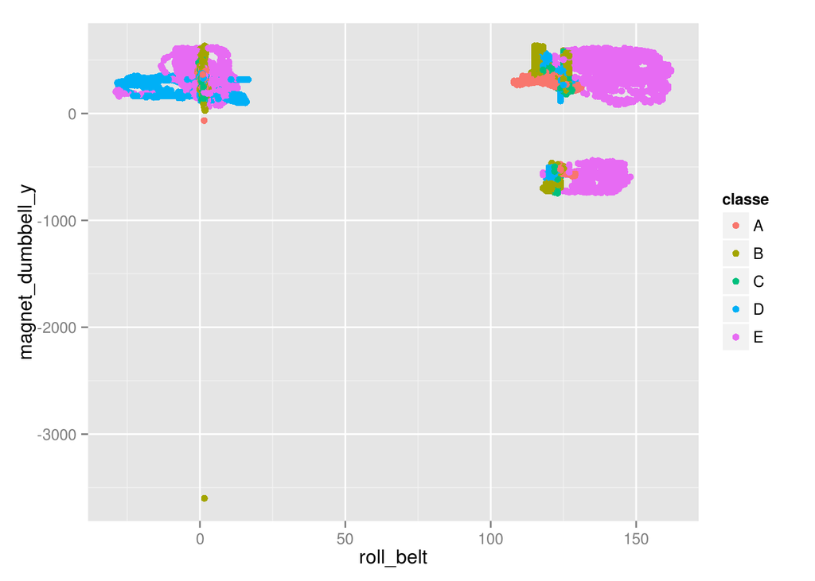

Looks like we have some obvious groupings already, We are on the right track.

Let’s plot those values to see how many variable to keep :

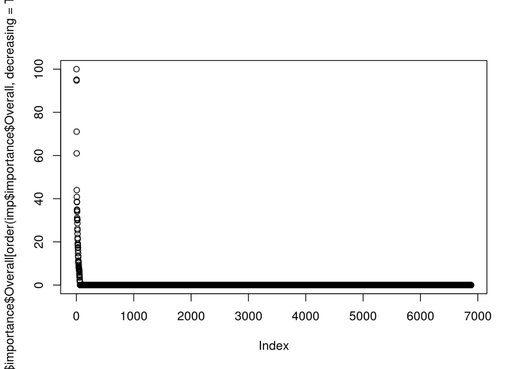

## Learning

So let’s learn on the full dataset now :

```r
rfModFit<-train(classe ~ roll_belt+magnet_dumbbell_y + magnet_arm_x+raw_timestamp_part_1+num_window, data=training, method="rf", ntree=10, nPerm=5, ntry=10)
rfModFit
```

```
## Random Forest
##
## 19622 samples
##    91 predictors
##     5 classes: 'A', 'B', 'C', 'D', 'E'
##
## No pre-processing
## Resampling: Bootstrapped (25 reps)
##
## Summary of sample sizes: 19622, 19622, 19622, 19622, 19622, 19622, ...
##
## Resampling results across tuning parameters:
##
##   mtry  Accuracy   Kappa      Accuracy SD   Kappa SD
##   2     0.9990590  0.9988092  0.0004404510  0.0005575458
##   3     0.9991584  0.9989351  0.0004871689  0.0006163612
##   5     0.9985887  0.9982143  0.0004499435  0.0005682800
##
## Accuracy was used to select the optimal model using  the largest value.
## The final value used for the model was mtry = 3.
```

As we can see this gives a good accuracy of 99.9%.

Since the trin algorithm made cross validation for us, let’s see the out of bag error :

```r
rfModFit$finalModel
```

```
##
## Call:
##  randomForest(x = x, y = y, ntree = 10, mtry = param$mtry, nPerm = 5,      ntry = 10)
##                Type of random forest: classification
##                      Number of trees: 10
## No. of variables tried at each split: 3
##
##         OOB estimate of  error rate: 0.25%
## Confusion matrix:
##      A    B    C    D    E class.error
## A 5499    7    0    0    0 0.001271340
## B    6 3731    7    1    1 0.004004271
## C    2    6 3377    0    1 0.002658004
## D    0    2    3 3180    3 0.002509410
## E    2    4    2    2 3566 0.002796421
```

The out of bag error is 0.25%

## Prediction

The only part left now is predicting the labeles of the test gestures :

```r
answers<-predict(rfModFit, testing)
answers
```

```
##  [1] B A B A A E D B A A B C B A E E A B B B
## Levels: A B C D E
```

Which gives the result of the assignment.